# 1 To start

# 3 MRIQC

To quickly check the validity of your BIDS dataset and to determine the quality of your scan (T1w or EPI), you can run MRIQC.

To run MRIQC, use the following command:

```bash
# TYPE THIS AGAIN, if the terminal session was closed
# ---------------------------------------------------
# ssh -Y compute-01
# module load collections/default

cd /data1/projects/fMRI-Course/Spinoza_Course/MRIQC/
python mriqc_tmux.py [main directory] [bids directory] [deriv directory] [temp directory]
                     [subject] [processessors] [your id]

# e.g. python mriqc_tmux.py data1 /data1/my_bids_data/ /data1/my_deriv_data/ /data1 my_temp_data/ sub-001 8 student01
```

The software will be run on a tmux (terminal multiplexer) and will take about an hour. Please, refer to the course of Tuesday for some details about the output of MRIQC.

# 4 FMRIPREP

Now that we have organized the files in BIDS format, we can start to preproces the data using FMRIPREP.

To run FMRIPREP, use the following command:

```bash
# TYPE THIS AGAIN, if the terminal session was closed
# ---------------------------------------------------
# ssh -Y compute-01
# module load collections/default

cd /data1/projects/fMRI-Course/Spinoza_Course/FRMIPREP/
python fmriprep_tmux.py [main directory] [bids directory] [deriv directory] [temp directory]
                        [subject] [processessors] [your id]
# e.g. python mriqc_tmux.py data1 /data1/my_bids_data/ /data1/my_deriv_data/ /data1 my_temp_data/ sub-001 8 student01
```

The software will be run on a tmux (terminal multiplexer) and will take about 10h to 12h to run. Please, refer to the course of Tuesday for some details about the output of FMRIPREP.

Now that we have organized the files in BIDS format, we can start running the preprocessing with FMRIPREP.

## 4.1 Inspecting the output

1. log into your tmux session again to check if the preprocessing is done.

```bash
tmux ls
tmux attach -tx
```

2. The output of FMRIPREP is saved in the deriv_data folder, where you can easily inspect the preprocessing by opening the html file. Given the class on Tuesday, how do you think the preprocessing looks? If you have doubts, call for one of us.
3. Again use fsleyes to load the preprocessed MNI_BOLD and T1w files. What is the difference with the raw BIDS files you saw?

## 4.2 Reporting

Every time you run FMRIPREP, the html file will contain a method section, where all the steps are carefully described. Please honor the developers by using this as a template for writing your method section for reports!

# 5 Lower level Analysis in FSL

Now that we have carefully preprocessed the recorded _bold.nii.gz files we want you to get a glimpse of how fMRI data is actually processed into the ’blobby’ images that you usually will find in most scientific papers. The analysis of the imaging recordings is commonly first done for each subject individually, and averaged on later stages to make inferences at group level. In this section we will just focus on one subject to give you an idea of how to analyse subjects individually. To do this, we will be using FSL FEAT.

## 5.1 First level analysis using FEAT

1. in your terminal type:

```bash
Feat
```

### 5.1.1 Data

The first thing we need to do is to define where FSL can find the preprocessed bold data. To do this please select the Data tab from Feat, and then click on Select 4D data. Then click on the yellow folder button to select the recorded ‘xx_bold_space-MNI152NLin2009cAsym_preproc.nii’ file. After clicking OK, you will immediately see some changes. FSL automatically searches for the number of recordings (Total volumes), and the timing between recordings (TR). This is also the window where you can change the high pass filter cutoff (but we will leave this for now).

[figure not shown]

Data

### 5.1.2 Preprocessing

Now go to the next tab (Pre-stats) to define your processing preferences. Because we have already done preprocessing with FMRIPREP we will turn everything off here except the option Highpass. Think about wheter or not you want some spatial smooting. Note that with the incorporation of the sine/cosine counfounds from FMRIPREP you won’t need to use highpass. But in this tutorial we won’t use those (but check the description online!).

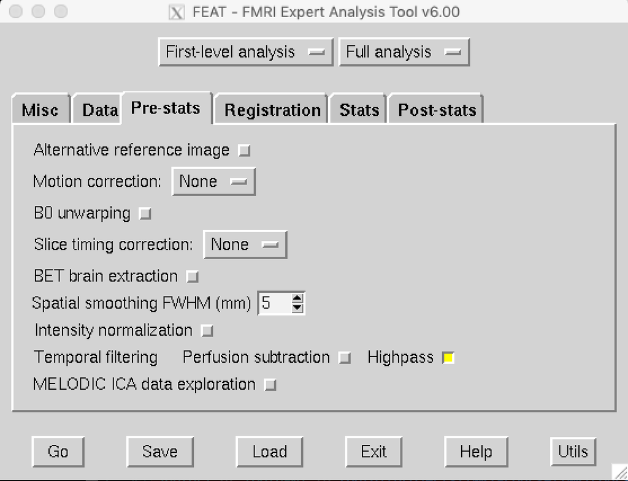

Pre-stats

### 5.1.3 Registration

FSL needs some input in the registration option to work on a higher level (group level) later. Note that this is not the registration that we will be using. As FMRIPREP has already done a much better job. To trick FSL choose the 6DOF option. For it all to work we also need to adjust some of the outputs, but that we will do after Feat has run.

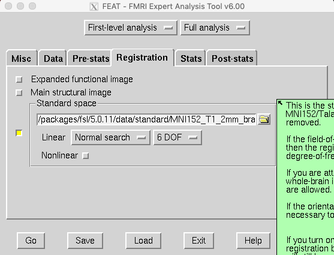

registration

### 5.1.4 Stats

The next step is to inform FSL what you have been recording (what was your participant doing at each recording time) and what analysis you would like to preform.

1. First prepare your timing files

```bash
cd /data1/projects/fMRI-course/Spinoza_Course/other
# again start R
R
```

```r
source('Make_fslevents.r')
base="/data1/projects/fMRI-course/"
datadir="/data1/projects/fMRI-course/[your folder]/bids_data/3T/sub-001/func"
outputdir=c('FSL','3T','Firstlevel',"sub-001","events")

make_fslevents(base,datadir,outputdir)
q()
```

```
cd /data1/projects/fMRI-course/[your folder]/FSL/3T/Firstlevel/sub-001/events
# check out the files created in /data1/projects/fMRI-course/[your folder]/FSL/3T/Firstlevel/sub-001/events
```

2. Now we will start the model set-up
- First turn on FILM prewhitening.
- Second, we need to exclude some of the confounds FMRIPREP computed. FMRIPREP outputs a lot of confound variables. A good grasp of all these variables is beyond this course and we advise you to carefully read everything online with the documentation of FMRIPREP. For now we only will use the FramewiseDisplayment, the 6 motion parameters and the aCompCor variables.
- In your terminal open the confounds file in the FMRIPREP func folder with the following command and remove all columns except the ones named above. Then save the file in *‘/data1/projects/fMRI-course/[your folder]/FSL/3T/Firstlevel/sub-001/events’* as confounds_feat.csv. Use the following command in terminal to open you file.

```bash
libreoffice5.2 sub-001_task-StopSignal_run-1_bold_confounds.tsv
```

- Third, tick the box add additional confounds, and select this confounds_feat.csv file that you just created.
- **Fourth**, we are going to set up our design! Select Full model setup. You will now see a new GUI appear to define your general linear model. Here we have to first specify all that is done by this participant and at what time. While in the scanner, our subject was preforming a stop signal task (as explained at the beginning of this week). Here, the following things could happen:
1. On trials where there is no instruction to stop
1. Participants can correctly choose a response ( Go; timing_GoCorrect.bfsl)
2. Participants can choose an incorrect response ( Error; timing_ChoiceError.bfsl)
2. On trials where there is a sudden stop instruction
1. Participants can be on time, and successfully stop their planned response (SS; timing_successful_stop.bfsl)
2. Participants can NOT stop on time and press, also called stop respond trials (FS; timing_Failed_stop.bfsl)
- **Fifth**,specify your predictions. First, change the total number of original EV’s to 4 (the events described above). Now we will define each event so that we can evaluate differences between the conditions in FSL. The first EV we will define as the trials where participants correctly choose a response (GO). For the option Basic shape choose ‘custom (3 column format)’, and then select the *timing_GoCorrect.bsfl* file with the yellow button tab. Then choose ‘Double-Gamma HRF’ for convolution, and make sure that both the ‘add temporal derivative’ (important for event related designs), and ‘apply temporal filtering’ boxes are selected (these should be yellow).

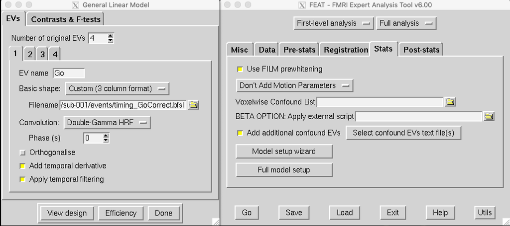

Feat defition of EV example

Now proceed to define all EV’s in the same manner with the following order of EV’s: 1) Go, 2) Error, 3) SS, 4) FS. Make sure to select the matching .bfsl file for each tab.

-The 6 step is to specify what you would be interested in to examine. First, for each participant, and later on a group level. For simplicity we will now only define a few options. But, in general, it is best to define all possible events or contrasts of interest already at individual subject level. For now we want to specify 1) the event for each condition, 2) activity levels when all conditions are defined as positive, and 3) activity when all conditions are defined as negative. To give you an idea of how differences between conditions are defined, we will also evaluate what regions in the brain are activated more during Stop trails when compared to Go trials. Note that this step can also be specified in a later step, when we are interested in activity levels across groups.

After the specification of all EV’s, select the tab Contrasts & F-tests. We will now define Each EV as an event of interest (contrast) and look at differences between Stop and Go. First, define each EV with the number 1 (see pic below), this defines the weight that is given to each event of interest.

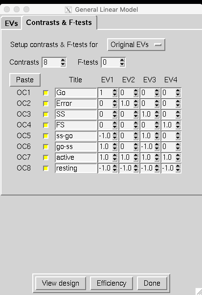

Feat contrasts

Those who scan the Stop-task are usually are interested in those regions within the brain that are activated more during Stop trials, when compared to the Go trials. To evaluate this we will give 1 as a weight to the Stop EV and a -1 as a weight to the Go EV. We will then do the same but ask what regions are activated more during Go [1] when compared to Stop [-1]. Finally, we would like to evaluate what regions of the brain are activated when all EV’s are defined as positive [1] or negative [-1]. The positive contrast contains 1s for every EV and it will show us where in the brain activity correlates positively with all EVs. In a way this contrast corresponds to the active state of the brain. The negative contrast contains -1s for every EV and it will show us where in the brain activity correlates negatively with all EVs. In a way this contrast corresponds to the resting state of the brain and usually shows activity along the mid line of the brain.

- *Finally*, don’t forget to evaluate your design matrix (also looking at what the confound parameters do)

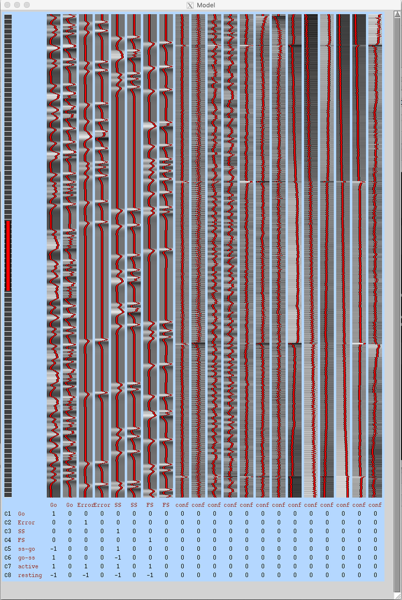

Feat design

and Efficiency.

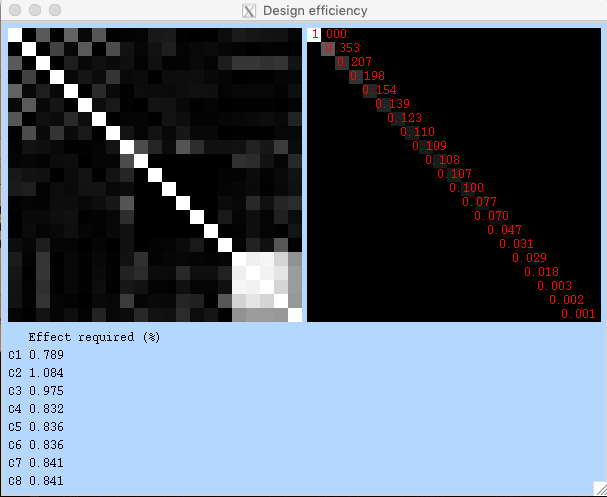

Feat efficiency

Use the green boxes or the fsl Feat help online to increase your understanding. After the evaluation, press ‘done’ to continue with your first level (individual subject run) design.

### 5.1.5 Post-stats tab

Keep in mind that cluster or voxel based thresholding is very important when we want to analyse multiple subjects but not handy when you want to evaluate whether 1 subject is showing meaningful activation.

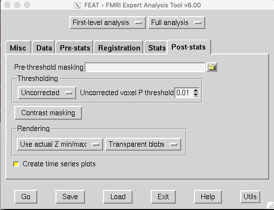

Feat Post-stats

## 5.2 save your design

Now save the design with the name first level.fsf in the FSL folder. Make sure to have read most green boxes and understood all the steps that we just went through before you continue. Do not press the Go button. Feat takes some time to process and for this we will work in tmux.

```bash
cd [path where you saved the firstlevel.fsf file]
# now type
tmux # followed by enter
feat firstlevel.fsf #enter
```

Your first level analysis is running!

## 5.3 set the registration right

for FSL to work on group level we need to work around it’s registration pypline. Carefully follow the instructions in the video! https://www.youtube.com/watch?time_continue=7&v=U3tG7JMEf7M

# 6 Check First level results

While feat is running, its output is placed in a *.feat* directory. When FEAT has finished with the analysis, you can view the results by opening report.html located in the Feat directory. Report.html is a webpage with a summary of the analysis. Once your feat has run navigate to this directory, and open the report.html file.

## 6.1 Feat Evaluation

# 7 Higher Level results

Statistical results of only one subject usually don’t tell us that much. With higher level analysis, inferences can be made about a whole group, of if you have different populations between groups. Unfortunately we don’t have the time to go over the different types of analysis one could do across a group of participants.

# 8 Conclusion

With this short introduction we never intended to teach you all there is to know about fMRI analysis, nor to make you ready for conducting your own experiments. Our main goal was to make you a little bit familiar with the pipeline of fMRI processing, experimental design, and some of the pitfalls that one should always evaluate. For those who are interested in learning more: FSL is a free analysis package for fMRI analysis and provides really good (to our opinion) instructions and courses to educate each of you in how fMRI data is best analysed.